# Finding the better option to buy a Hyundai Tucson car

The idea is to find some options to buy a Hyundai Tucson car. There is a specialized site to buy and sell cars and motorbikes (http://www.webmotors.com.br). The cars/motorbikes can be new or used. There are many advertisements that are published every day in this place. So many options: color, year, model, price, etc. And I visit this site every day to find out a good opportunity.

How work: *I created an app in python to extract (crawler) these data from this site. Then I saved these data in a sqlite database, called 'crawler-motors.db'. The next step was to analyze these data. So, I created this notebook. This notebook has seven parts. In general I use pandas for data manipulation, some statistical analysis and matplotlib to create some graphics. Also, I am using approaches of machine learning to do a prediction of the sale's price throught by a linear regression model.*

```python
import pandas as pd
import numpy as np
import sqlite3 as bd
import matplotlib.pyplot as plt

%matplotlib inline
```

```python
path = '/home/lserra/Temp/'
database = 'crawler-motors.db'
```

```python
cnn = bd.connect(path + database)
df = pd.read_sql_query('select * from webmotors;', cnn)
```

```python
df.shape
```

```
(4385, 21)
```

```python
df.columns
```

```
Index(['anuncio', 'estado', 'cidade', 'marca', 'modelo', 'modelo_marca', 'mmv',
       'combustivel', 'cambio', 'cod_anuncio', 'cor', 'preco', 'carroceria',
       'ano_modelo', 'tipo_pessoa', 'tipo_carro', 'km', 'final_placa',
       'dt_anuncio', 'fonte', 'dt_extraction'],
      dtype='object')
```

```python
df.dtypes
```

```
anuncio           object
estado            object
cidade            object
marca             object
modelo            object
modelo_marca      object
mmv               object
combustivel       object
cambio            object
cod_anuncio       object
cor               object
preco            float64
carroceria        object
ano_modelo         int64
tipo_pessoa       object
tipo_carro        object
km                object
final_placa       object
dt_anuncio        object
fonte             object
dt_extraction     object
dtype: object
```

```python
df.head()
```

|  | anuncio | estado | cidade | marca | modelo | modelo_marca | mmv | combustivel | cambio | cod_anuncio | ... | preco | carroceria | ano_modelo | tipo_pessoa | tipo_carro | km | final_placa | dt_anuncio | fonte | dt_extraction |
| --- | --- | --- | --- | --- | --- | --- | --- | --- | --- | --- | --- | --- | --- | --- | --- | --- | --- | --- | --- | --- | --- |
| 0 | det_anunc_c | São Paulo (SP) | Sumaré | HYUNDAI | TUCSON | HYUNDAI\|TUCSON | HYUNDAI\|TUCSON\|2.0 MPFI GLS 16V 143CV 2WD GASO... | Gasolina | Automática | 18520094 | ... | 36890.0 | Utilitário esportivo | 2013 | concessionaria | usado | None | None | None | webmotors | 22-12-2016 |
| 1 | det_anunc_c | São Paulo (SP) | Campinas | HYUNDAI | TUCSON | HYUNDAI\|TUCSON | HYUNDAI\|TUCSON\|2.0 MPFI GLS 16V 143CV 2WD GASO... | Gasolina | Automática | 18421807 | ... | 39900.0 | Utilitário esportivo | 2013 | concessionaria | usado | None | None | None | webmotors | 22-12-2016 |
| 2 | det_anunc_c | São Paulo (SP) | São Paulo | HYUNDAI | TUCSON | HYUNDAI\|TUCSON | HYUNDAI\|TUCSON\|2.0 MPFI GL 16V 142CV 2WD GASOL... | Gasolina | Manual | 18495068 | ... | 41790.0 | Utilitário esportivo | 2013 | concessionaria | usado | None | None | None | webmotors | 22-12-2016 |
| 3 | det_anunc_c | São Paulo (SP) | São Paulo | HYUNDAI | TUCSON | HYUNDAI\|TUCSON | HYUNDAI\|TUCSON\|2.0 MPFI GL 16V 142CV 2WD GASOL... | Gasolina | Manual | 17887895 | ... | 41800.0 | Utilitário esportivo | 2013 | pessoafisica | usado | None | None | None | webmotors | 22-12-2016 |
| 4 | det_anunc_c | Goiás (GO) | Goiânia | HYUNDAI | TUCSON | HYUNDAI\|TUCSON | HYUNDAI\|TUCSON\|2.0 MPFI GLS 16V 143CV 2WD FLEX... | Gasolina e álcool | Automática | 18507774 | ... | 41990.0 | Utilitário esportivo | 2013 | concessionaria | usado | None | None | None | webmotors | 22-12-2016 |

5 rows × 21 columns

# Part 1 - Quantitative Analysis

## 1. Qty. advertisements by date extraction

```python
sel_cols = ['dt_extraction']
analysis1 = df.groupby(sel_cols)
results1 = analysis1[sel_cols].count()
```

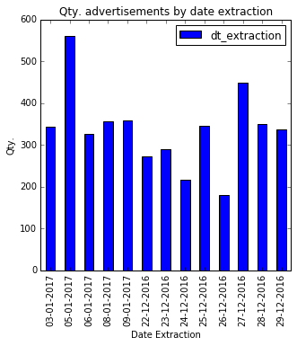

```python
results1.plot(kind='bar', figsize=[5, 5])
plt.title(u'Qty. advertisements by date extraction')
plt.ylabel(u'Qty.')
plt.xlabel(u'Date Extraction')
plt.show()
```

## 2. Qty. advertisements by State

```python
sel_cols = ['estado']
analysis2 = df.groupby(sel_cols)
results2 = analysis2[sel_cols].count()
```

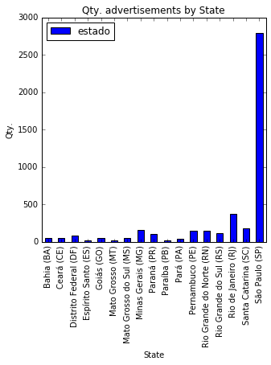

```python
results2.plot(kind='bar', figsize=[5,5])
plt.title(u'Qty. advertisements by State')
plt.ylabel(u'Qty.')
plt.xlabel(u'State')
plt.show()
```

## 3. Qty. advertisements by Fuel

```python
sel_cols = ['combustivel']
analysis3 = df.groupby(sel_cols)
results3 = analysis3[sel_cols].count()
```

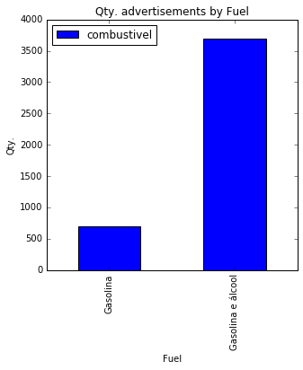

```python
results3.plot(kind='bar', figsize=[5,5])
plt.title(u'Qty. advertisements by Fuel')
plt.ylabel(u'Qty.')
plt.xlabel(u'Fuel')
plt.show()
```

## 4. Qty. advertisements by Year/Model

```python
sel_cols = ['ano_modelo']
analysis4 = df.groupby(sel_cols)
results4 = analysis4[sel_cols].count()
```

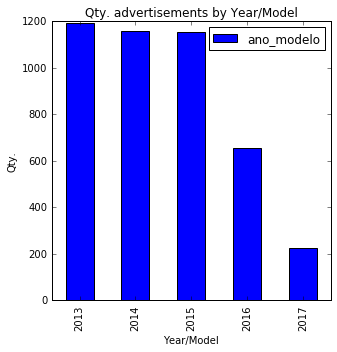

```python
results4.plot(kind='bar', figsize=[5,5])
plt.title(u'Qty. advertisements by Year/Model')
plt.ylabel(u'Qty.')
plt.xlabel(u'Year/Model')
plt.show()
```

## 5. Qty. advertisements by Color

```python
sel_cols = ['cor']
analysis5 = df.groupby(sel_cols)
results5 = analysis5[sel_cols].count()
```

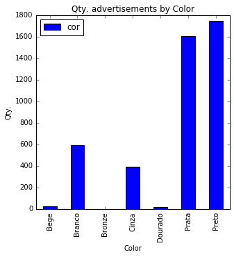

```python
results5.plot(kind='bar', figsize=[5,5])
plt.title(u'Qty. advertisements by Color')
plt.ylabel(u'Qty.')
plt.xlabel(u'Color')
plt.show()
```

## 6. Qty. advertisements by Category

```python
sel_cols = ['tipo_pessoa']
analysis6 = df.groupby(sel_cols)
results6 = analysis6[sel_cols].count()
```

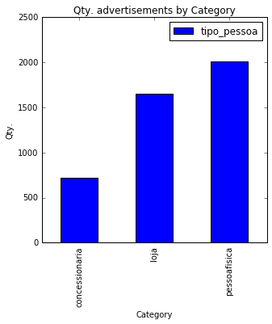

```python
results6.plot(kind='bar', figsize=[5,5])
plt.title(u'Qty. advertisements by Category')
plt.ylabel(u'Qty.')
plt.xlabel(u'Category')
plt.show()
```

## 7. Qty. advertisements by Gear

```python
sel_cols = ['cambio']
analysis7 = df.groupby(sel_cols)
results7 = analysis7[sel_cols].count()
```

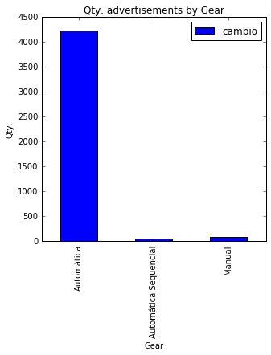

```python
results7.plot(kind='bar', figsize=[5,5])
plt.title(u'Qty. advertisements by Gear')
plt.ylabel(u'Qty.')
plt.xlabel(u'Gear')
plt.show()
```

# Part 2 - Statistical Analysis

## 1. Sale's price (min and max)

```python
pmin = df[df['preco'] == df['preco'].min()]
pmin
```

|  | anuncio | estado | cidade | marca | modelo | modelo_marca | mmv | combustivel | cambio | cod_anuncio | ... | preco | carroceria | ano_modelo | tipo_pessoa | tipo_carro | km | final_placa | dt_anuncio | fonte | dt_extraction |
| --- | --- | --- | --- | --- | --- | --- | --- | --- | --- | --- | --- | --- | --- | --- | --- | --- | --- | --- | --- | --- | --- |
| 0 | det_anunc_c | São Paulo (SP) | Sumaré | HYUNDAI | TUCSON | HYUNDAI\|TUCSON | HYUNDAI\|TUCSON\|2.0 MPFI GLS 16V 143CV 2WD GASO... | Gasolina | Automática | 18520094 | ... | 36890.0 | Utilitário esportivo | 2013 | concessionaria | usado | None | None | None | webmotors | 22-12-2016 |
| 273 | det_anunc_c | São Paulo (SP) | Sumaré | HYUNDAI | TUCSON | HYUNDAI\|TUCSON | HYUNDAI\|TUCSON\|2.0 MPFI GLS 16V 143CV 2WD GASO... | Gasolina | Automática | 18520094 | ... | 36890.0 | Utilitário esportivo | 2013 | concessionaria | usado | None | None | None | webmotors | 23-12-2016 |
| 563 | det_anunc_c | São Paulo (SP) | Sumaré | HYUNDAI | TUCSON | HYUNDAI\|TUCSON | HYUNDAI\|TUCSON\|2.0 MPFI GLS 16V 143CV 2WD GASO... | Gasolina | Automática | 18520094 | ... | 36890.0 | Utilitário esportivo | 2013 | concessionaria | usado | None | None | None | webmotors | 24-12-2016 |
| 779 | det_anunc_c | São Paulo (SP) | Sumaré | HYUNDAI | TUCSON | HYUNDAI\|TUCSON | HYUNDAI\|TUCSON\|2.0 MPFI GLS 16V 143CV 2WD GASO... | Gasolina | Automática | 18520094 | ... | 36890.0 | Utilitário esportivo | 2013 | concessionaria | usado | None | None | None | webmotors | 25-12-2016 |

4 rows × 21 columns

```python
pmax = df[df['preco'] == df['preco'].max()]
pmax
```

|  | anuncio | estado | cidade | marca | modelo | modelo_marca | mmv | combustivel | cambio | cod_anuncio | ... | preco | carroceria | ano_modelo | tipo_pessoa | tipo_carro | km | final_placa | dt_anuncio | fonte | dt_extraction |
| --- | --- | --- | --- | --- | --- | --- | --- | --- | --- | --- | --- | --- | --- | --- | --- | --- | --- | --- | --- | --- | --- |
| 272 | det_anunc_c | São Paulo (SP) | Santo André | HYUNDAI | TUCSON | HYUNDAI\|TUCSON | HYUNDAI\|TUCSON\|2.0 MPFI GLS 16V 143CV 2WD FLEX... | Gasolina e álcool | Automática | 18024676 | ... | 103000.0 | Utilitário esportivo | 2017 | loja | usado | None | None | None | webmotors | 22-12-2016 |
| 562 | det_anunc_c | São Paulo (SP) | Santo André | HYUNDAI | TUCSON | HYUNDAI\|TUCSON | HYUNDAI\|TUCSON\|2.0 MPFI GLS 16V 143CV 2WD FLEX... | Gasolina e álcool | Automática | 18024676 | ... | 103000.0 | Utilitário esportivo | 2017 | loja | usado | None | None | None | webmotors | 23-12-2016 |
| 778 | det_anunc_c | São Paulo (SP) | Santo André | HYUNDAI | TUCSON | HYUNDAI\|TUCSON | HYUNDAI\|TUCSON\|2.0 MPFI GLS 16V 143CV 2WD FLEX... | Gasolina e álcool | Automática | 18024676 | ... | 103000.0 | Utilitário esportivo | 2017 | loja | usado | None | None | None | webmotors | 24-12-2016 |
| 1124 | det_anunc_c | São Paulo (SP) | Santo André | HYUNDAI | TUCSON | HYUNDAI\|TUCSON | HYUNDAI\|TUCSON\|2.0 MPFI GLS 16V 143CV 2WD FLEX... | Gasolina e álcool | Automática | 18024676 | ... | 103000.0 | Utilitário esportivo | 2017 | loja | usado | None | None | None | webmotors | 25-12-2016 |
| 1471 | det_anunc_c | São Paulo (SP) | Santo André | HYUNDAI | TUCSON | HYUNDAI\|TUCSON | HYUNDAI\|TUCSON\|2.0 MPFI GLS 16V 143CV 2WD FLEX... | Gasolina e álcool | Automática | 18024676 | ... | 103000.0 | Utilitário esportivo | 2017 | loja | usado | None | None | None | webmotors | 27-12-2016 |
| 1753 | det_anunc_c | São Paulo (SP) | Santo André | HYUNDAI | TUCSON | HYUNDAI\|TUCSON | HYUNDAI\|TUCSON\|2.0 MPFI GLS 16V 143CV 2WD FLEX... | Gasolina e álcool | Automática | 18024676 | ... | 103000.0 | Utilitário esportivo | 2017 | loja | usado | None | None | None | webmotors | 27-12-2016 |
| 2102 | det_anunc_c | São Paulo (SP) | Santo André | HYUNDAI | TUCSON | HYUNDAI\|TUCSON | HYUNDAI\|TUCSON\|2.0 MPFI GLS 16V 143CV 2WD FLEX... | Gasolina e álcool | Automática | 18024676 | ... | 103000.0 | Utilitário esportivo | 2017 | loja | usado | None | None | None | webmotors | 28-12-2016 |
| 2438 | det_anunc_c | São Paulo (SP) | Santo André | HYUNDAI | TUCSON | HYUNDAI\|TUCSON | HYUNDAI\|TUCSON\|2.0 MPFI GLS 16V 143CV 2WD FLEX... | Gasolina e álcool | Automática | 18024676 | ... | 103000.0 | Utilitário esportivo | 2017 | loja | usado | None | None | None | webmotors | 29-12-2016 |
| 2782 | det_anunc_c | São Paulo (SP) | Santo André | HYUNDAI | TUCSON | HYUNDAI\|TUCSON | HYUNDAI\|TUCSON\|2.0 MPFI GLS 16V 143CV 2WD FLEX... | Gasolina e álcool | Automática | 18024676 | ... | 103000.0 | Utilitário esportivo | 2017 | loja | usado |  |  |  | webmotors | 03-01-2017 |
| 3138 | det_anunc_c | São Paulo (SP) | Santo André | HYUNDAI | TUCSON | HYUNDAI\|TUCSON | HYUNDAI\|TUCSON\|2.0 MPFI GLS 16V 143CV 2WD FLEX... | Gasolina e álcool | Automática | 18024676 | ... | 103000.0 | Utilitário esportivo | 2017 | loja | usado |  |  |  | webmotors | 05-01-2017 |
| 4025 | det_anunc_c | São Paulo (SP) | Santo André | HYUNDAI | TUCSON | HYUNDAI\|TUCSON | HYUNDAI\|TUCSON\|2.0 MPFI GLS 16V 143CV 2WD FLEX... | Gasolina e álcool | Automática | 18024676 | ... | 103000.0 | Utilitário esportivo | 2017 | loja | usado |  |  |  | webmotors | 08-01-2017 |
| 4384 | det_anunc_c | São Paulo (SP) | Santo André | HYUNDAI | TUCSON | HYUNDAI\|TUCSON | HYUNDAI\|TUCSON\|2.0 MPFI GLS 16V 143CV 2WD FLEX... | Gasolina e álcool | Automática | 18024676 | ... | 103000.0 | Utilitário esportivo | 2017 | loja | usado |  |  |  | webmotors | 09-01-2017 |

12 rows × 21 columns

## 2. Sale's price (Histogram)

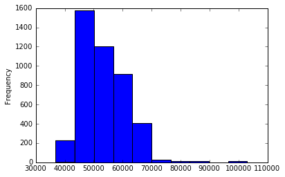

```python
pv = df['preco']
# pv.convert_objects(convert_numeric=True).plot.hist(bins=10)
pv.plot.hist(bins=10)
```

## 3. Sale's price (mean by state)

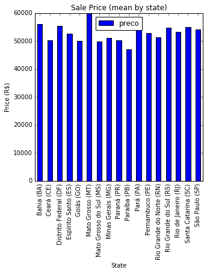

```python
pv_by_uf = df[['estado', 'preco']].groupby(['estado']).mean()
pv_by_uf.plot(kind='bar', figsize=[5,5])
plt.title(u'Sale Price (mean by state)')
plt.ylabel(u'Price (R$)')
plt.xlabel(u'State')
plt.show()
```

# Part 3 - Creating KPIs

## 1. Price by Year

```python
df.dtypes
```

```
anuncio           object
estado            object
cidade            object
marca             object
modelo            object
modelo_marca      object
mmv               object
combustivel       object
cambio            object
cod_anuncio       object
cor               object
preco            float64
carroceria        object
ano_modelo         int64
tipo_pessoa       object
tipo_carro        object
km                object
final_placa       object
dt_anuncio        object
fonte             object
dt_extraction     object
dtype: object
```

```python
pa = df[['cod_anuncio','estado','combustivel','cambio','cor','ano_modelo','tipo_pessoa','preco']]
pa['preco_by_ano'] = df['preco']/df['ano_modelo']
pa.head()
```

|  | cod_anuncio | estado | combustivel | cambio | cor | ano_modelo | tipo_pessoa | preco | preco_by_ano |
| --- | --- | --- | --- | --- | --- | --- | --- | --- | --- |
| 0 | 18520094 | São Paulo (SP) | Gasolina | Automática | Preto | 2013 | concessionaria | 36890.0 | 18.325882 |
| 1 | 18421807 | São Paulo (SP) | Gasolina | Automática | Preto | 2013 | concessionaria | 39900.0 | 19.821162 |
| 2 | 18495068 | São Paulo (SP) | Gasolina | Manual | Preto | 2013 | concessionaria | 41790.0 | 20.760060 |
| 3 | 17887895 | São Paulo (SP) | Gasolina | Manual | Preto | 2013 | pessoafisica | 41800.0 | 20.765027 |
| 4 | 18507774 | Goiás (GO) | Gasolina e álcool | Automática | Preto | 2013 | concessionaria | 41990.0 | 20.859414 |

## 2. Advertisement Time

```python
ta = pa.copy()
ta['qtde_dias'] = 1
ta.head()
```

|  | cod_anuncio | estado | combustivel | cambio | cor | ano_modelo | tipo_pessoa | preco | preco_by_ano | qtde_dias |
| --- | --- | --- | --- | --- | --- | --- | --- | --- | --- | --- |
| 0 | 18520094 | São Paulo (SP) | Gasolina | Automática | Preto | 2013 | concessionaria | 36890.0 | 18.325882 | 1 |
| 1 | 18421807 | São Paulo (SP) | Gasolina | Automática | Preto | 2013 | concessionaria | 39900.0 | 19.821162 | 1 |
| 2 | 18495068 | São Paulo (SP) | Gasolina | Manual | Preto | 2013 | concessionaria | 41790.0 | 20.760060 | 1 |
| 3 | 17887895 | São Paulo (SP) | Gasolina | Manual | Preto | 2013 | pessoafisica | 41800.0 | 20.765027 | 1 |
| 4 | 18507774 | Goiás (GO) | Gasolina e álcool | Automática | Preto | 2013 | concessionaria | 41990.0 | 20.859414 | 1 |

```python
ta['qtde_dias'] = ta.groupby(['cod_anuncio']).transform(len)
ta.head()
```

|  | cod_anuncio | estado | combustivel | cambio | cor | ano_modelo | tipo_pessoa | preco | preco_by_ano | qtde_dias |
| --- | --- | --- | --- | --- | --- | --- | --- | --- | --- | --- |
| 0 | 18520094 | São Paulo (SP) | Gasolina | Automática | Preto | 2013 | concessionaria | 36890.0 | 18.325882 | 4 |
| 1 | 18421807 | São Paulo (SP) | Gasolina | Automática | Preto | 2013 | concessionaria | 39900.0 | 19.821162 | 8 |
| 2 | 18495068 | São Paulo (SP) | Gasolina | Manual | Preto | 2013 | concessionaria | 41790.0 | 20.760060 | 4 |
| 3 | 17887895 | São Paulo (SP) | Gasolina | Manual | Preto | 2013 | pessoafisica | 41800.0 | 20.765027 | 14 |
| 4 | 18507774 | Goiás (GO) | Gasolina e álcool | Automática | Preto | 2013 | concessionaria | 41990.0 | 20.859414 | 14 |

```python
ta.shape
```

```
(4385, 10)
```

# Part 4 - Selecting data for a deep analysis

```python
kpi = ta.copy()
```

```python
kpi.dtypes
```

```
cod_anuncio      object
estado           object
combustivel      object
cambio           object
cor              object
ano_modelo        int64
tipo_pessoa      object
preco           float64
preco_by_ano    float64
qtde_dias         int64
dtype: object
```

```python
knd = kpi.drop_duplicates([u'cod_anuncio'])  # knd = kpi no duplicates
knd.shape
```

```
(541, 10)
```

```python
# knd = knd[knd['combustivel'] == u'Gasolina e álcool']
knd = knd[knd[u'cambio'] == u'Automática']
knd = knd[knd[u'cor'] == u'Preto']
# knd = knd[knd['ano_modelo'] == 2013]
knd = knd[knd[u'tipo_pessoa'] != u'pessoafisica']
```

```python
knd.shape
```

```
(109, 10)
```

```python
knd.sort_values(u'preco_by_ano').head()
```

|  | cod_anuncio | estado | combustivel | cambio | cor | ano_modelo | tipo_pessoa | preco | preco_by_ano | qtde_dias |
| --- | --- | --- | --- | --- | --- | --- | --- | --- | --- | --- |
| 0 | 18520094 | São Paulo (SP) | Gasolina | Automática | Preto | 2013 | concessionaria | 36890.0 | 18.325882 | 4 |
| 1 | 18421807 | São Paulo (SP) | Gasolina | Automática | Preto | 2013 | concessionaria | 39900.0 | 19.821162 | 8 |
| 4 | 18507774 | Goiás (GO) | Gasolina e álcool | Automática | Preto | 2013 | concessionaria | 41990.0 | 20.859414 | 14 |
| 10 | 18451424 | São Paulo (SP) | Gasolina | Automática | Preto | 2013 | loja | 42990.0 | 21.356185 | 9 |
| 15 | 18456711 | São Paulo (SP) | Gasolina | Automática | Preto | 2013 | concessionaria | 43490.0 | 21.604570 | 5 |

```
                          estado
estado
Bahia (BA)                     2
Ceará (CE)                     1
Distrito Federal (DF)          2
Espírito Santo (ES)            2
Goiás (GO)                     2
Minas Gerais (MG)              5
Paraná (PR)                    6
Pará (PA)                      1
Pernambuco (PE)                5
Rio Grande do Norte (RN)       3
Rio Grande do Sul (RS)         5
Rio de Janeiro (RJ)            6
Santa Catarina (SC)            8
São Paulo (SP)                61
```

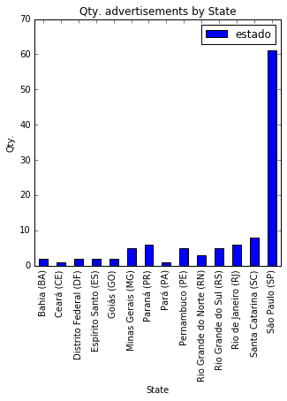

```python
sel_cols = [u'estado']
analysis = knd.groupby(sel_cols)
results = analysis[sel_cols].count()
print(results)

results.plot(kind='bar', figsize=[5,5])
plt.title(u'Qty. advertisements by State')
plt.ylabel(u'Qty.')
plt.xlabel(u'State')
plt.show()
```

```
                   combustivel
combustivel
Gasolina                    21
Gasolina e álcool           88
```

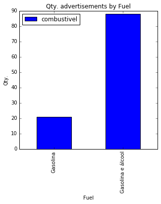

```python
sel_cols = [u'combustivel']
analysis = knd.groupby(sel_cols)
results = analysis[sel_cols].count()
print(results)

results.plot(kind='bar', figsize=[5,5])
plt.title(u'Qty. advertisements by Fuel')
plt.ylabel(u'Qty.')
plt.xlabel(u'Fuel')
plt.show()
```

```
            ano_modelo
ano_modelo
2013                31
2014                39
2015                17
2016                16
2017                 6
```

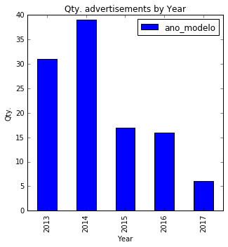

```python
sel_cols = [u'ano_modelo']
analysis = knd.groupby(sel_cols)
results = analysis[sel_cols].count()
print(results)

results.plot(kind='bar', figsize=[5,5])
plt.title(u'Qty. advertisements by Year')
plt.ylabel(u'Qty.')
plt.xlabel(u'Year')
plt.show()
```

```
                tipo_pessoa
tipo_pessoa
concessionaria           39
loja                     70
```

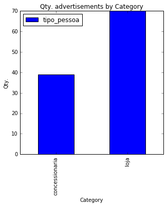

```python
sel_cols = [u'tipo_pessoa']
analysis = knd.groupby(sel_cols)
results = analysis[sel_cols].count()
print(results)

results.plot(kind='bar', figsize=[5,5])
plt.title(u'Qty. advertisements by Category')
plt.ylabel(u'Qty.')
plt.xlabel(u'Category')
plt.show()
```

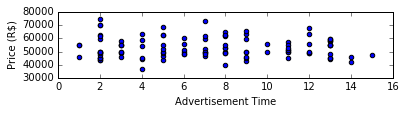

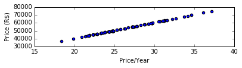

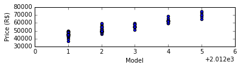

```python
plt.figure(1)
plt.subplot(311)
plt.scatter(knd.qtde_dias, knd.preco)
plt.xlabel(u'Advertisement Time')
plt.ylabel(u'Price (R$)')

plt.figure(2)
plt.subplot(312)
plt.scatter(knd.preco_by_ano, knd.preco)
plt.xlabel(u'Price/Year')
plt.ylabel(u'Price (R$)')

plt.figure(3)
plt.subplot(313)
plt.scatter(knd.ano_modelo, knd.preco)
plt.xlabel(u'Model')
plt.ylabel(u'Price (R$)')

plt.show()
```

# Part 5 - Applying machine learning to predict the sale's price

*The machine learning algorithm used to do this prediction is the generalized linear regression.*

```python
from sklearn import datasets, linear_model
```

```python
# Function to get data
def get_data(data_frame):
    """
    This function get our data into X values (qty_days) Y values (price)
    """
    x_parameter = []
    y_parameter = []
    for single_qty_days, single_price_value in zip(data_frame['qtde_dias'], data_frame['preco']):
        x_parameter.append(int(single_qty_days))
        y_parameter.append(int(single_price_value))
    return x_parameter,y_parameter
```

*We converted data to X_parameters and Y_parameter so let’s fit our X_parameters and Y_parameters to Linear Regression model. So we gonna write a function which will take x_parameters, y_parameter and the value you gonna predict as input and return the θ0 ,θ1 and predicted value.*

```python
# Function for fitting data to linear model
def linear_model_main(X_parameters, Y_parameters, predict_value):
    # Create linear regression object
    X_parameters = np.array(X_parameters).reshape(len(X_parameters), -1)

    regr = linear_model.LinearRegression()
    regr.fit(X_parameters, Y_parameters)
    predict_outcome = regr.predict(predict_value)
    predictions = {}
    predictions['intercept'] = regr.intercept_
    predictions['coefficient'] = regr.coef_
    predictions['predicted_value'] = predict_outcome
    return predictions
```

```python
# Function to show the resutls of linear fit model
def show_linear_line(X_parameters, Y_parameters):
    # Create linear regression object
    X_parameters = np.array(X_parameters).reshape(len(X_parameters), -1)

    regr = linear_model.LinearRegression()
    regr.fit(X_parameters, Y_parameters)
    plt.scatter(X_parameters,Y_parameters,color='blue')
    plt.plot(X_parameters,regr.predict(X_parameters),color='red',linewidth=4)
    plt.xticks(())
    plt.yticks(())
    plt.show()
```

# Part 6 - Predicting the sale's price of the Tucson 2013

*- What shall be the sale's price from this vehicule, if the time of advertisement is greater than fifteen days ?*

```
>> Intercept value =  44234.4314849
>> coefficient =  [ 171.09967919]
>> Predicted value =  [ 47656.42506874]
```

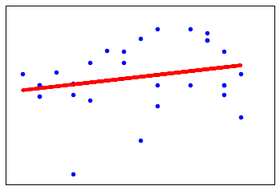

```python
df = knd.copy()
df = df[df['ano_modelo'] == 2013]
x, y = get_data(df[['preco', 'qtde_dias']])
predict_value = 20
result = linear_model_main(x, y, predict_value)
print(">> Intercept value = " , result['intercept'])
print(">> coefficient = " , result['coefficient'])
print(">> Predicted value = ", result['predicted_value'])
show_linear_line(x,y)
```

# Part 7 - Predicting the sale's price of the Tucson 2014

*- What shall be the sale's price from this vehicule, if the time of advertisement is greater than fifteen days ?*

```
>> Intercept value =  48955.1183427
>> coefficient =  [ 327.27344395]
>> Predicted value =  [ 55500.58722156]
```

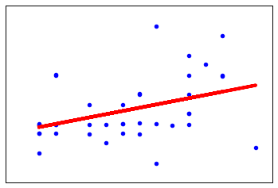

```python
df = knd.copy()
df = df[df['ano_modelo'] == 2014]
x, y = get_data(df[['preco', 'qtde_dias']])
predict_value = 20
result = linear_model_main(x, y, predict_value)
print(">> Intercept value = " , result['intercept'])
print(">> coefficient = " , result['coefficient'])
print(">> Predicted value = ", result['predicted_value'])
show_linear_line(x,y)
```

*These were my notice that can be expanded or contributed for who can be interesting. If you want contact me to explain some doubts, make suggestions or criticals...or to know my services - please send me an e-mail: laercio.serra@gmail.com, or visit my website for more details, in: http://lserra.datafresh.com.br*